# Machine Learning Project

Balaji Rajan

4/8/2021

# Introduction

Using devices such as Jawbone Up, Nike FuelBand, and Fitbit it is now possible to collect a large amount of data about personal activity relatively inexpensively. These type of devices are part of the quantified self movement – a group of enthusiasts who take measurements about themselves regularly to improve their health, to find patterns in their behavior, or because they are tech geeks. One thing that people regularly do is quantify how much of a particular activity they do, but they rarely quantify how well they do it.

In this project, your goal will be to use data from accelerometers on the belt, forearm, arm, and dumbell of 6 participants. They were asked to perform barbell lifts correctly and incorrectly in 5 different ways.

The goal of this project is to predict the manner in which they did the exercise. This is the “classe” variable in the training set. The project will also use prediction model to predict 20 different test cases.

## Steps to be followed in this project

A. We will load the data files into variable

B. We will clean the files of inconsistent data

C. We will do exploratory analysis

D. We will then perform prediction using some of the Machine Learning techniques

E. We will discuss the analysis and the results

## Loading Libraries

```r
library(caret)
library(ggplot2)
library(rattle)
```

# Load Data

## Load Training Data

```r
TrainData<-read.csv("C:/Users/balaj/OneDrive/My Learnings/Data Science/Course 8/Project/pml-training.csv")
dim(TrainData)
```

```
## [1] 19622   160
```

## Load Test Data

```r
TestData<-read.csv("C:/Users/balaj/OneDrive/My Learnings/Data Science/Course 8/Project/pml-testing.csv")
dim(TestData)
```

```
## [1]  20 160
```

Let us look at the data table structure

```r
str(TrainData)
```

```
## 'data.frame':    19622 obs. of  160 variables:
##  $ X                       : int  1 2 3 4 5 6 7 8 9 10 ...
##  $ user_name               : chr  "carlitos" "carlitos" "carlitos" "carlitos" ...
##  $ raw_timestamp_part_1    : int  1323084231 1323084231 1323084231 1323084232 1323084232 1323084232 1323084232 1323084232 1323084232 1323084232 ...
##  $ raw_timestamp_part_2    : int  788290 808298 820366 120339 196328 304277 368296 440390 484323 484434 ...
##  $ cvtd_timestamp          : chr  "05/12/2011 11:23" "05/12/2011 11:23" "05/12/2011 11:23" "05/12/2011 11:23" ...
##  $ new_window              : chr  "no" "no" "no" "no" ...
##  $ num_window              : int  11 11 11 12 12 12 12 12 12 12 ...
##  $ roll_belt               : num  1.41 1.41 1.42 1.48 1.48 1.45 1.42 1.42 1.43 1.45 ...
##  $ pitch_belt              : num  8.07 8.07 8.07 8.05 8.07 8.06 8.09 8.13 8.16 8.17 ...
##  $ yaw_belt                : num  -94.4 -94.4 -94.4 -94.4 -94.4 -94.4 -94.4 -94.4 -94.4 -94.4 ...
##  $ total_accel_belt        : int  3 3 3 3 3 3 3 3 3 3 ...
##  $ kurtosis_roll_belt      : chr  "" "" "" "" ...
##  $ kurtosis_picth_belt     : chr  "" "" "" "" ...
##  $ kurtosis_yaw_belt       : chr  "" "" "" "" ...
```

[output cut: 86 more lines]

## Data Observations

A. First 7 columns are identifying the participant, timestamp etc. Things unrelated to the model building

B. There are lot of records with NA or NULL values. They will skew the model’s predicting capability

C. The data needs to be scrubbed for the predictions to be accurate

## Criteria for cleaning the data

A. Let us remove the columns where majority (90%) of data in NULL or NA

B. Let us also remove the first 7 columns which are not adding any information to the model

### On the Training Dataset

```r
cols_remove<-which(colSums(is.na(TrainData) | TrainData=="")>0.9*dim(TrainData)[1])

TrainDataClean<-TrainData[,-cols_remove]
TrainDataClean<-TrainDataClean[,-c(1:7)]
dim(TrainDataClean)
```

```
## [1] 19622    53
```

### On the Testing Dataset

```r
TestDataClean<-TestData[,-cols_remove]
TestDataClean<-TestDataClean[,-c(1:7)]
dim(TestDataClean)
```

```
## [1] 20 53
```

#### Let us look at the structure of our clean data

```r
str(TrainDataClean)
```

```
## 'data.frame':    19622 obs. of  53 variables:
##  $ roll_belt           : num  1.41 1.41 1.42 1.48 1.48 1.45 1.42 1.42 1.43 1.45 ...
##  $ pitch_belt          : num  8.07 8.07 8.07 8.05 8.07 8.06 8.09 8.13 8.16 8.17 ...
##  $ yaw_belt            : num  -94.4 -94.4 -94.4 -94.4 -94.4 -94.4 -94.4 -94.4 -94.4 -94.4 ...
##  $ total_accel_belt    : int  3 3 3 3 3 3 3 3 3 3 ...
##  $ gyros_belt_x        : num  0 0.02 0 0.02 0.02 0.02 0.02 0.02 0.02 0.03 ...
##  $ gyros_belt_y        : num  0 0 0 0 0.02 0 0 0 0 0 ...
##  $ gyros_belt_z        : num  -0.02 -0.02 -0.02 -0.03 -0.02 -0.02 -0.02 -0.02 -0.02 0 ...
##  $ accel_belt_x        : int  -21 -22 -20 -22 -21 -21 -22 -22 -20 -21 ...
##  $ accel_belt_y        : int  4 4 5 3 2 4 3 4 2 4 ...
##  $ accel_belt_z        : int  22 22 23 21 24 21 21 21 24 22 ...
##  $ magnet_belt_x       : int  -3 -7 -2 -6 -6 0 -4 -2 1 -3 ...
##  $ magnet_belt_y       : int  599 608 600 604 600 603 599 603 602 609 ...
##  $ magnet_belt_z       : int  -313 -311 -305 -310 -302 -312 -311 -313 -312 -308 ...
##  $ roll_arm            : num  -128 -128 -128 -128 -128 -128 -128 -128 -128 -128 ...
```

[output cut: 39 more lines]

Now that we have the clean data, we will start the Machine Learning algorithm process

#### Create Cross Validation data set

We will create the test data of 20 scenarios for presenting the outcome for use in production. This sample will not be used till we finalize the prediction methos we will use.

Hence we will partition the training dataset for validation purposes

```r
set.seed(12345)
inTrain<-createDataPartition(TrainDataClean$classe, p=0.75, list=FALSE)
Train<-TrainDataClean[inTrain,]
Test<-TrainDataClean[-inTrain,]
dim(Train)
```

```
## [1] 14718    53
```

```r
dim(Test)
```

```
## [1] 4904   53
```

# Prediction

## We are now ready to run the training and prediction using the various models

We will use

A. Classification Tree

B. Random Forest

3. Gradient Boosting Method

## Classification Tree Method

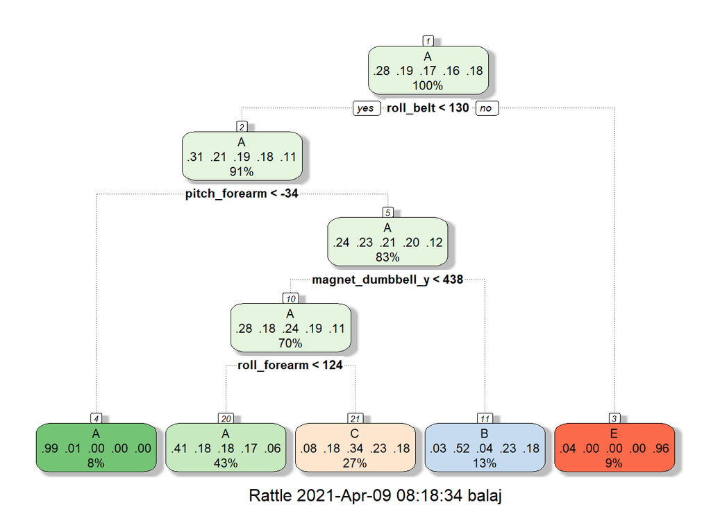

```r
trControl<-trainControl(method="cv", number=5)
model_CT<-train(classe~., data=Train, method="rpart", trControl=trControl)
fancyRpartPlot(model_CT$finalModel)
```

Using the trained model for prediction

```r
pred_CT<-predict(model_CT, newdata=Test)
fac_Test<-as.factor(Test$classe)
confMat_CT<-confusionMatrix(fac_Test, pred_CT)
confMat_CT$table
```

```
##           Reference
## Prediction    A    B    C    D    E
##          A 1252   30   90    0   23
##          B  396  317  236    0    0
##          C  434   24  397    0    0
##          D  343  151  310    0    0
##          E  114  132  229    0  426
```

```r
confMat_CT$overall
```

```
##       Accuracy          Kappa  AccuracyLower  AccuracyUpper   AccuracyNull
##      0.4877651      0.3306104      0.4736841      0.5018607      0.5177406
## AccuracyPValue  McnemarPValue
##      0.9999874            NaN
```

## Random Forest Method

```r
model_RF<-train(classe~., data=Train, method="rf", verbose=FALSE, trControl=trControl)
```

Random Forest Model Output

```r
print(model_RF)
```

```
## Random Forest
##
## 14718 samples
##    52 predictor
##     5 classes: 'A', 'B', 'C', 'D', 'E'
##
## No pre-processing
## Resampling: Cross-Validated (5 fold)
## Summary of sample sizes: 11774, 11774, 11774, 11775, 11775
## Resampling results across tuning parameters:
##
##   mtry  Accuracy   Kappa
##    2    0.9919826  0.9898578
##   27    0.9913030  0.9889986
##   52    0.9851202  0.9811766
##
## Accuracy was used to select the optimal model using the largest value.
## The final value used for the model was mtry = 2.
```

Prediction

```r
pred_RF<-predict(model_RF,newdata=Test)
confMat_RF<-confusionMatrix(fac_Test,pred_RF)
confMat_RF$table
```

```
##           Reference
## Prediction    A    B    C    D    E
##          A 1395    0    0    0    0
##          B    1  947    1    0    0
##          C    0    6  848    1    0
##          D    0    0   15  784    5
##          E    0    0    0    1  900
```

```r
confMat_RF$overall[1]
```

```
##  Accuracy
## 0.9938825
```

```r
names(model_RF$finalModel)
```

```
##  [1] "call"            "type"            "predicted"       "err.rate"
##  [5] "confusion"       "votes"           "oob.times"       "classes"
##  [9] "importance"      "importanceSD"    "localImportance" "proximity"
## [13] "ntree"           "mtry"            "forest"          "y"
## [17] "test"            "inbag"           "xNames"          "problemType"
## [21] "tuneValue"       "obsLevels"       "param"
```

```r
confMat_RF$overall[1]
```

```
##  Accuracy
## 0.9938825
```

We will show some of the plots of Random Forest and analyse the findings

A. Let us look at the number of predictors Random Forest took and how its accuracy changed

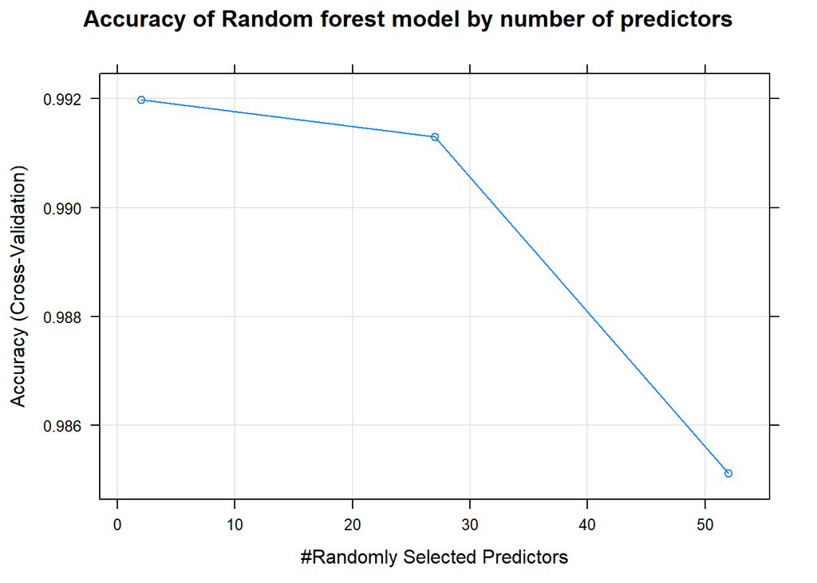

```r
plot(model_RF,main="Accuracy of Random forest model by number of predictors")
```

B. Let us look at the model error by number of trees

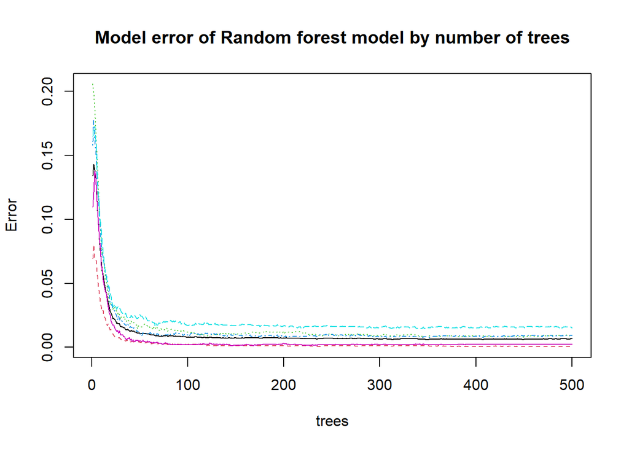

```r
plot(model_RF$finalModel,main="Model error of Random forest model by number of trees")
```

C. Let us look at the predictors that Random Forest determined important

```r
MostImpVars <- varImp(model_RF)
MostImpVars
```

```
## rf variable importance
##
##   only 20 most important variables shown (out of 52)
##
##                      Overall
## roll_belt             100.00
## yaw_belt               84.34
## magnet_dumbbell_z      70.43
## pitch_belt             68.57
## magnet_dumbbell_y      66.35
## pitch_forearm          64.98
## magnet_dumbbell_x      58.47
## roll_forearm           54.69
## magnet_belt_z          48.50
## accel_dumbbell_y       47.87
## accel_belt_z           47.45
## magnet_belt_y          46.91
## roll_dumbbell          44.95
## accel_dumbbell_z       38.86
## roll_arm               36.37
## accel_forearm_x        34.36
## gyros_belt_z           32.40
## accel_arm_x            30.69
## accel_dumbbell_x       30.69
## total_accel_dumbbell   29.33
```

## Gradient boosting method

One last model, we will choose GBM method for predicting

### Train the model

```r
model_GBM<-train(classe~., method="gbm", data=Train, verbose=FALSE)

print(model_GBM)
```

```
## Stochastic Gradient Boosting
##
## 14718 samples
##    52 predictor
##     5 classes: 'A', 'B', 'C', 'D', 'E'
##
## No pre-processing
## Resampling: Bootstrapped (25 reps)
## Summary of sample sizes: 14718, 14718, 14718, 14718, 14718, 14718, ...
## Resampling results across tuning parameters:
##
##   interaction.depth  n.trees  Accuracy   Kappa
##   1                   50      0.7451887  0.6768221
##   1                  100      0.8158113  0.7668533
##   1                  150      0.8505658  0.8109067
##   2                   50      0.8515368  0.8119111
##   2                  100      0.9058309  0.8808243
##   2                  150      0.9303975  0.9119226
##   3                   50      0.8954676  0.8676615
##   3                  100      0.9402448  0.9243877
##   3                  150      0.9594102  0.9486417
##
## Tuning parameter 'shrinkage' was held constant at a value of 0.1
##
## Tuning parameter 'n.minobsinnode' was held constant at a value of 10
## Accuracy was used to select the optimal model using the largest value.
## The final values used for the model were n.trees = 150, interaction.depth =
##  3, shrinkage = 0.1 and n.minobsinnode = 10.
```

Testing the model

```r
pred_GBM<-predict(model_GBM,newdata=Test)
confMat_GBM<-confusionMatrix(pred_GBM,fac_Test)
```

Let us look at some of the graphs created by Gradient Boosting Classification

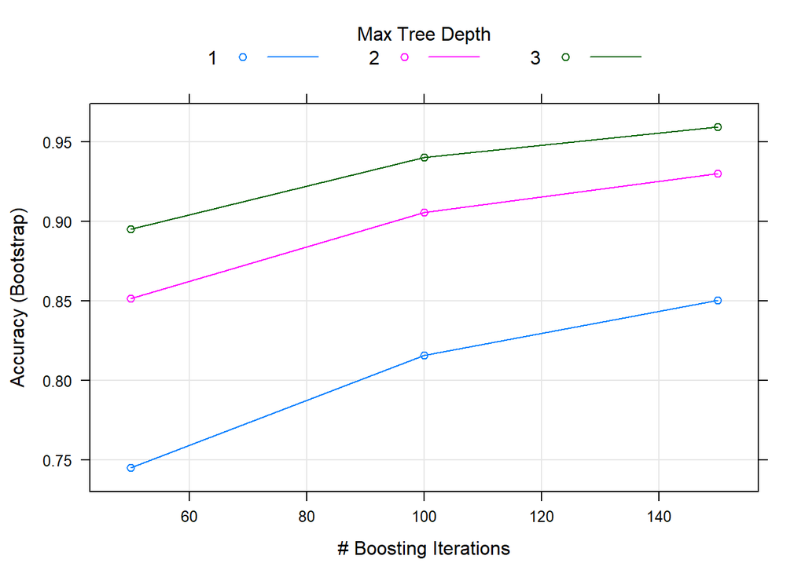

```r
plot(model_GBM)
```

```r
confMat_GBM$table
```

```
##           Reference
## Prediction    A    B    C    D    E
##          A 1375   25    0    0    0
##          B   15  894   24    2   10
##          C    1   29  816   33   13
##          D    4    1   15  762   13
##          E    0    0    0    7  865
```

```r
confMat_GBM$overall[1]
```

```
##  Accuracy
## 0.9608483
```

# Conclusion

In the three models we described, we found Random FOrest gave the best accuracy, whereas Gradient Boost took the most computation time (and there is a need to speak about the efficiency of the model in a trade-off.)

When we hand over the prediction model to the deployment team, we have to baseline the model performance against the cross validation data…this data has not been seen by any of the models yet.

```r
FinalPred<-predict(model_RF, newdata=TestDataClean)
FinalPred
```

```
##  [1] B A B A A E D B A A B C B A E E A B B B
## Levels: A B C D E
```